# Hunter_Raymond_HW1

Ray Hunter

2023-01-27

```r
knitr::opts_chunk$set(echo=TRUE, warning=FALSE, message=FALSE,  results=FALSE)
library(tidyverse)
library(here)
library(janitor)
library(readxl)
library(lubridate)
library(patchwork)
library(AICcmodavg)
library(broom)
library(knitr)
```

### Task 1

Data from Knapp et al. (2020) was used to visually represent how Sierra Nevada Yellow Legged Frog (*Rana muscosa*) population abundances have changed over the span of the study (1995-2002) throughout the southern Sierra Nevada mountains. Furthermore, we analyzed how the abundances of different frog lifestages have changed over this duration. This information is important to understand for managing wild populations of this endangered species so we can efficiently allocate our resources to ensure their protection.

**Reference:** Knapp, R.A., C. Pavelka, E.E. Hegeman, and T.C. Smith. 2020. The Sierra Lakes Inventory Project: Non-Native fish and community composition of lakes and ponds in the Sierra Nevada, California ver 2. Environmental Data Initiative. https://doi.org/10.6073/pasta/d835832d7fd00d9e4466e44eea87fab3

#### 1) Wrangling the Data:

Here the master data sheet was read in and wrangled to select the key characteristics analyzed in the study.

```r
#read in the master data sheet
frog_data <- read_excel(here("sierra_amphibians.xlsx"))

#creating data table 1 for graph A
ylf_mod1 <- frog_data %>%
  #transform date into year
   mutate(survey_date = year(survey_date)) %>%
   #filter out just yellow legged frogs and everything but eggmass
filter(amphibian_species == "RAMU", amphibian_life_stage != "EggMass")  %>%
 group_by(survey_date, amphibian_life_stage) %>%
  summarise(amphibian_number = sum(amphibian_number, na.rm = TRUE ) )




#creating data table 2 for graph B
top_5_counts <- frog_data %>%
  #just adults/subadults and yellow legged frogs
  filter(amphibian_species == "RAMU", amphibian_life_stage %in% c("Adult", "SubAdult")) %>%
  #grouping lakes by id
  group_by(lake_id) %>%
  #summarizing total count of amphibians
  summarize(total_count = sum(amphibian_number)) %>%
   relocate(total_count) %>%
  #making lake id a factor
  mutate(lake_id = factor(lake_id)) %>%
  #choosing the 5 most abundant lakes
  slice_max(total_count, n = 5) %>%
  #put in descending order
  arrange(-total_count)
top_5_counts$lake_id <- sub("^", "Lake ", top_5_counts$lake_id)
```

#### 2) Creating Graphs:

Two graphs were created that represent three amphibian life stage (adult, saubadult, and tadpole) abundances over time and most highly populated lakes in the study.

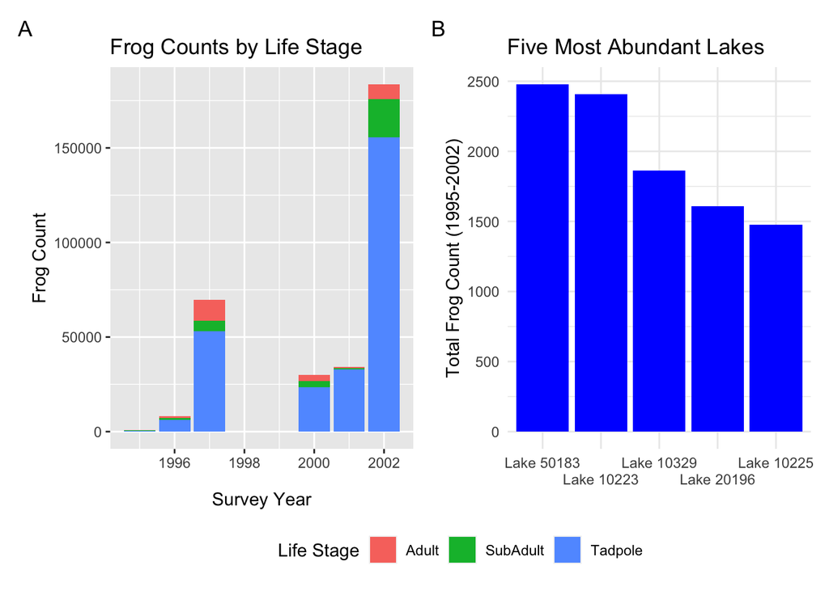

```r
#making the first stacked bar chart of frog coutns by life stage
plot_1 <- ggplot(data = ylf_mod1,
                 aes(x = survey_date, y = amphibian_number, fill = amphibian_life_stage)) +
ggtitle("Frog Counts by Life Stage") +
  geom_col() +
 labs(x = "Survey Year", y = "Frog Count") +
  labs(fill='Life Stage')



#making the second bar chart of frog counts by most abundant lake
plot_2 <- ggplot(data = top_5_counts, aes(x = fct_reorder(lake_id, -total_count), y = total_count)) +
  ggtitle("Five Most Abundant Lakes") +
  #making the bar chart blue
  geom_col(fill = "blue") +
  #labeling the axis
  scale_x_discrete(guide = guide_axis(n.dodge=2)) +
  labs(y = "Total Frog Count (1995-2002)", x = "") +
  theme_minimal()

#patching together the plots
plot_patch <- plot_1  + plot_2  + plot_layout(guides = 'collect') & theme( legend.position = 'bottom')


#adding plot annotations A and B
 plot_patch +  plot_annotation(
  tag_levels = "A")
```

*B:* Total adult and subadult *Rana muscosa* counts from all years in the five most abundant lakes. Tadpoles and eggmass lifestages were excluded.

### Task 2

In Task 2 we analyze the key variables that explain and predict oxygen saturation through linear regression modeling and cross validation methods. The goal is to come up with a model that best explains the existing data and also predicts oxygen saturation from future samples. The data used here is provided by CalCOFI cruises that has been collecting hydrographic and biological data since 1949.

**Reference:** *calcofi_seawater_samples*. CalCOFI. (2022, July 6). Retrieved February 2, 2023, from https://calcofi.org/

#### Model Creation

Three different linear models were created to represent how different abiotic factors are explaining oxygen concentration:

**Model 1:** Oxygen saturation as a function of water temperature, salinity, and phosphate concentration.

**Model 2:** Oxygen saturation as a function of water temperature, salinity, phosphate concentration, and depth.

**Model 3:** Oxygen saturation as a function of water temperature, salinity, phosphate concentration, depth, and nitrite concentration.

```r
#read in and wrangle the data
water_samples <- read_csv(here("calcofi_seawater_samples.csv")) %>%
  drop_na() %>%
  rename(oxy = o2sat,
    temp = t_deg_c,
    depth=depth_m,
    sal=salinity,
    phos = po4u_m,
    nit = no2u_m)


#assigning variables
f1 <- oxy ~ temp + sal + phos
f2 <- oxy ~ temp + sal + phos + depth
f3 <- oxy ~ temp + sal + phos + depth + nit

#model 1 creation
mdl1 <- lm(f1, data = water_samples)
#model 2 creation
mdl2 <- lm(f2, data = water_samples)
#model 3 creation
mdl3 <- lm(f3, data = water_samples)




summary(mdl1)
AIC(mdl1)
BIC(mdl1)

summary(mdl2)
AIC(mdl2)
BIC(mdl2)

summary(mdl3)
AIC(mdl3)
BIC(mdl3)
```

#### AIC and BIC Comparison

```r
AIC(mdl1, mdl2, mdl3)

BIC(mdl1, mdl2, mdl3)


AICcmodavg::AICc(mdl1)
AICc(mdl2)
AICc(mdl3)

AICcmodavg::aictab(list(mdl1, mdl2, mdl3))
AICcmodavg::bictab(list(mdl1, mdl2, mdl3))
```

```r
# Listing the AIC values
AIC_list<-c(AIC(mdl1), AIC(mdl2), AIC(mdl3))
BIC_list <- c(BIC(mdl1), BIC(mdl2), BIC(mdl3))

# merging data and selecting specific columns
model_output <-rbind(data.frame(glance(mdl1)),data.frame(glance(mdl2)), data.frame(glance(mdl3))) %>% select(adj.r.squared, AIC, BIC)

# calculate delta AIC or the distance in AIC from the lowest value (the best model) and the other models.
model_output <- mutate(model_output, delta.AIC = AIC-min(AIC_list))
model_output <- mutate(model_output, delta.BIC = BIC-min(BIC_list))
model_output$model<-c( "Model 1","Model 2", "Model 3")
model_output<-model_output[,c("model","adj.r.squared", "AIC", "delta.AIC", "BIC", "delta.BIC" )]



kable(model_output, format = "markdown", digits = 3,caption = "*Figure 2*: Model outputs showing the adjusted R^2^ value, AIC/BIC values, and delta AIC/BIC values for all models.")
```

*Figure 2*: Model outputs showing the adjusted R<sup>2</sup> value, AIC/BIC values, and delta AIC/BIC values for all models.

| model | adj.r.squared | AIC | delta.AIC | BIC | delta.BIC |
| --- | --- | --- | --- | --- | --- |
| Model 1 | 0.954 | 618.387 | 6.008 | 631.413 | 0.798 |
| Model 2 | 0.956 | 615.702 | 3.323 | 631.333 | 0.718 |
| Model 3 | 0.958 | 612.379 | 0.000 | 630.615 | 0.000 |

#### 10 Fold Cross Validation Test and Results

A 10 fold cross validation test was performed to test which model was most accurate at predicting oxygen saturation. Result from the test suggest that Model 1 is the best model out of the three for predicting oxygen saturation. Model 1 will predict oxygen saturation the most accurately when given a new set of data compared to the other two models as it had the lowest root mean squared error value.

```r
#creating a training data set
folds <- 10
fold_vec <- rep(1:folds, length.out = nrow(water_samples))

set.seed(42)

water_fold <- water_samples %>%
  mutate(group = sample(fold_vec, size = n(), replace = FALSE))
table(water_fold$group)

### creating the first fold
test_df <- water_fold %>%
  filter(group == 1)

train_df <- water_fold %>%
  filter(group != 1)







#creating a function to calculate root mean squared error
calc_rmse <- function(x, y) {
  rmse <- (x - y)^2 %>% mean() %>% sqrt()
  return(rmse)
}


#creating linear models with the training data set
training_lm1 <- lm(f1, data = train_df)
training_lm2 <- lm(f2, data = train_df)
training_lm3 <- lm(f3, data = train_df)






#using models to predict the actual data set
predict_test <- test_df %>%
  mutate(model1 = predict(training_lm1, test_df),
         model2 = predict(training_lm2, test_df),
         model3 = predict(training_lm3, test_df))

rmse_predict_test <- predict_test %>%
  summarize(rmse_mdl1 = calc_rmse(model1, oxy),
            rmse_mdl2 = calc_rmse(model2, oxy),
            rmse_mdl3 = calc_rmse(model3, oxy))
```

```r
tenfold_output <- rmse_predict_test %>%
  rename(Model_1_rmse = rmse_mdl1,Model_2_rmse = rmse_mdl2, Model_3_rmse = rmse_mdl3 )
kable(tenfold_output, format = "markdown", digits = 3,caption = "*Figure 3*: Root mean squared error outputs for each model from the 10 fold cross validation test. The lower the error the more accurate the model. Model 3 has the lowest error.")
```

| Model_1_rmse | Model_2_rmse | Model_3_rmse |
| --- | --- | --- |
| 8.859 | 9.498 | 9.196 |

#### K Fold Cross Validation and Results

To further explore the models’ ability to predict oxygen saturation, a K fold cross validation test was performed. Results from the test suggest that Model 3 is the most accurate in predicting oxygen concentration compared to Models 1 and 2 as it had the smallest average root mean squared error value.

```r
rmse_df <- data.frame()

for(i in 1:folds) {
  # i <- 1
  kfold_test_df <- water_fold %>%
    filter(group == i)
  kfold_train_df <- water_fold %>%
    filter(group != i)

  kfold_lm1 <- lm(f1, data = kfold_train_df)
  kfold_lm2 <- lm(f2, data = kfold_train_df)
  kfold_lm3 <- lm(f3, data = kfold_train_df)


  kfold_pred_df <- kfold_test_df %>%
    mutate(mdl1 = predict(kfold_lm1, kfold_test_df),
           mdl2 = predict(kfold_lm2, .),
           mdl3 = predict(kfold_lm3, .))
  kfold_rmse <- kfold_pred_df %>%
    summarize(rmse_mdl1 = calc_rmse(mdl1, oxy),
              rmse_mdl2 = calc_rmse(mdl2, oxy),
              rmse_mdl3 = calc_rmse(mdl3, oxy),
              test_gp = i)

  rmse_df <- bind_rows(rmse_df, kfold_rmse)
}


kfold_output <- rmse_df %>%
  summarize(Model_1_rmse = mean(rmse_mdl1),
           Model_2_rmse = mean(rmse_mdl2),
           Model_3_rmse =mean(rmse_mdl3))
kable(kfold_output,  format = "markdown", digits = 3,caption = "*Figure 4*: The average root mean squared error outputs for each model from the K fold cross validation test. The lower the error the more accurate the model. Model 3 has the lowest error.")
```

*Figure 4*: The average root mean squared error outputs for each model from the K fold cross validation test. The lower the error the more accurate the model. Model 3 has the lowest error.

| Model_1_rmse | Model_2_rmse | Model_3_rmse |
| --- | --- | --- |
| 4.977 | 4.876 | 4.795 |

#### Conclusion

Out of all the models tested, Model 3 explains oxygen saturation in the data set the best as suggested by it having the lowest AIC and BIC values. Furthermore, Model 3 is also the best model in predicting oxygen saturation from new data sets as shown in the K fold cross validation test yielding the lowest average root mean squared error. However, a 10 fold cross validation test suggests that Model 1 is better at predicting oxygen saturation than Model 3. Because the K fold test incorporate more folds and the entire data set, we chose to use the findings from this test indicating that Model 3 is the most accurate model. In conclusion, oxygen saturation can most accurately be explained and predicted based off of a combination of water temperature, salinity, phosphate concentration, depth, and nitrite concentration.

```r
final_mdl <- lm(f3, data = water_samples)


out_3_tidy <- tidy(mdl3)

kable(out_3_tidy, format = "markdown", digits = 3, caption = "*Figure 5*: Output for Model 3 showing the coefficients for each variable, standard error, statistic value, and p value. temp = temperature, sal = salinity, phos = phosphorous concentration, depth = depth, and nit = nitrate concentration")
```

| term | estimate | std.error | statistic | p.value |
| --- | --- | --- | --- | --- |
| (Intercept) | 149.935 | 93.391 | 1.605 | 0.112 |
| temp | -0.468 | 0.415 | -1.126 | 0.263 |
| sal | -0.787 | 2.930 | -0.269 | 0.789 |
| phos | -37.375 | 2.453 | -15.237 | 0.000 |
| depth | -0.018 | 0.016 | -1.124 | 0.264 |
| nit | 14.664 | 6.469 | 2.267 | 0.026 |

Model 3 Equation:
$$\operatorname{oxy} = \alpha + \beta_{1}(\operatorname{temp}) +
\beta_{2}(\operatorname{sal}) + \beta_{3}(\operatorname{phos}) +
\beta_{4}(\operatorname{depth}) + \beta_{5}(\operatorname{nit}) +
\epsilon$$

Model 3 with coefficients:
$$\begin{aligned}
\operatorname{\widehat{oxy}} &= 149.94 - 0.47(\operatorname{temp}) -
0.79(\operatorname{sal}) - 37.37(\operatorname{phos})\ - \\
&\quad 0.02(\operatorname{depth}) + 14.66(\operatorname{nit})
\end{aligned}$$